# Factors That Affect Insurance Charge to Patient

Sean Schilk

9/20/2025

# 1 Introduction

The general purpose of multiple linear regression (MLR) is to identify a relationship in an explicit functional form between explanatory variables or predictors and the dependent response variable, which is what will be explored in this project.

# 2 Data Set

I’m using a data set provided by Mosap Abdel-Ghany on Kaggle called “Medical Insurance Cost Dataset”. The data was collected from a collection of 1338 individuals from medical insurance records.

## 2.1 Data Description

The variables names in the data set and their variable type are the following:

- age (numeric)
- sex (character)
- BMI (numeric) - a measure of body fat based on height and weigh
- children (numeric) - Number of children covered by health insurance
- smoker (character) - Smoking status of the beneficiary
- region (character)- Residential region in the US
- charges (numeric) - Medical insurance cost billed to the beneficiary

## 2.2 Practical Question

The primary question is to identify the association between insurance charge and relevant predictor variables available in the data set.

# 3 Exploratory Data Analysis

We first explore the pairwise association between variables in the dataset. Since BMI and age are included, we begin by plotting these two variables to examine whether body mass index appears to vary systematically with age.

To start, we load the data to R.

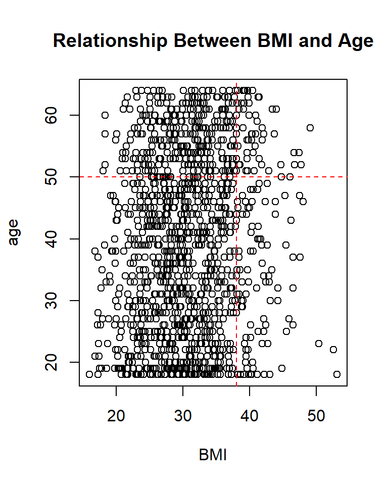

```r
# Read in dataset
library(readr)
insurance <- read_csv("https://raw.githubusercontent.com/sschilk/MySTA321/refs/heads/main/insurance.csv", show_col_types = FALSE)

# BMI and Age will be used to make a map in the upcoming analysis.

BMI <- insurance$bmi
age <- insurance$age
plot(BMI, age, main = "Relationship Between BMI and Age")
abline(v=38, h=50, col="red", lty=2)
```

We use BMI and Age to define a group variable, **highRisk.group**, in the following.

**highRisk.group = TRUE** if BMI > 38 AND age > 50; **highRisk.group = FALSE** otherwise.

We also turn the variable **smoker** into an indicator variable.

```r
highRisk.group = (BMI > 38) & (age > 50)       # define the highRisk.group variable

insurance$highRisk.group = as.character(highRisk.group)   # convert logical to character

# convert smoker variable ("yes"/"no") into numeric indicator (1 = yes, 0 = no)
insurance$smoker.ind = ifelse(insurance$smoker == "yes", 1, 0) # 1 for smoker


# keep only relevant variables for candidate models
final.data = insurance[, c("children", "smoker.ind", "charges", "highRisk.group")]

# show first rows
kable(head(final.data))
```

| children | smoker.ind | charges | highRisk.group |
| --- | --- | --- | --- |
| 0 | 1 | 16884.924 | FALSE |
| 1 | 0 | 1725.552 | FALSE |
| 3 | 0 | 4449.462 | FALSE |
| 0 | 0 | 21984.471 | FALSE |
| 0 | 0 | 3866.855 | FALSE |
| 0 | 0 | 3756.622 | FALSE |

# 4 Fitting MLR to Data

We start the search process for the final model.

## 4.1 Full model and diagnostics

We start with a linear model that includes all predictor variables.

```r
full.model = lm(charges ~ ., data = final.data)
kable(summary(full.model)$coef, caption ="Statistics of Regression Coefficients")
```

Statistics of Regression Coefficients

|  | Estimate | Std. Error | t value | Pr(>\|t\|) |
| --- | --- | --- | --- | --- |
| (Intercept) | 7417.0173 | 291.9098 | 25.408597 | 0.00e+00 |
| children | 659.0809 | 165.8539 | 3.973864 | 7.45e-05 |
| smoker.ind | 23667.5798 | 495.1060 | 47.803057 | 0.00e+00 |
| highRisk.groupTRUE | 7062.6952 | 1015.7184 | 6.953399 | 0.00e+00 |

Next, we conduct residual diagnostic analysis to check the validity of the model before making an inference about the model.

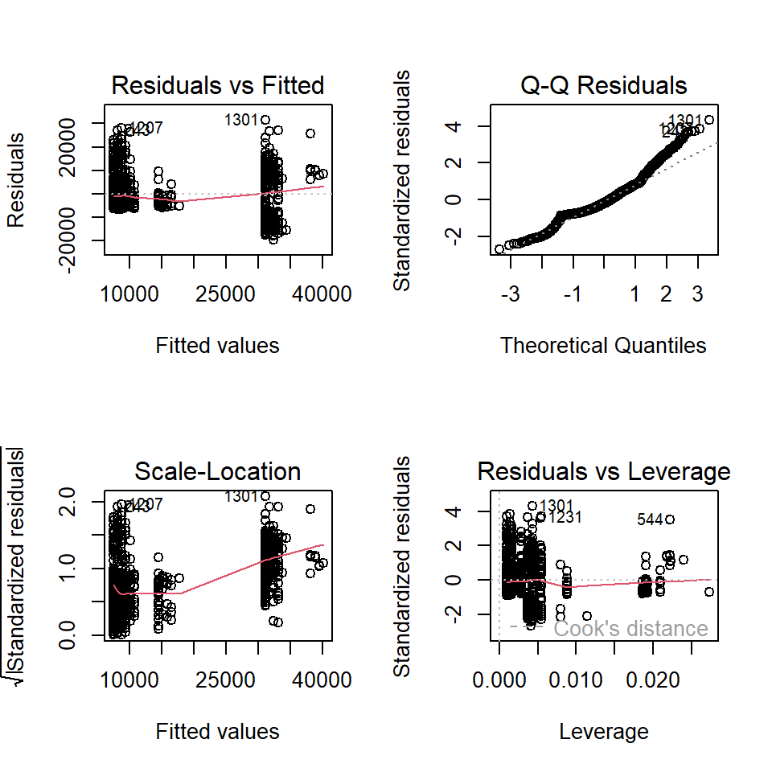

Residual plots of the full model

```r
par(mfrow=c(2,2))
plot(full.model)
```

We can see from the residual plots that there are some minor violations:

- the variance of the residuals is not constant.
- the QQ plot indicates the distribution of residuals is off the normal distribution.
- The residual plot seems to have a weak curve pattern.

We first perform Box-Cox transformation to correct the non-constant variance and correct the non-normality of the QQ plot.

```r
vif(full.model)
```

```
      children     smoker.ind highRisk.group
      1.001069       1.000425       1.001386
```

The VIF indices show that there is no significant issues on multicollinearity, as they are close to 1. We can also make a bar plot for the VIFs.

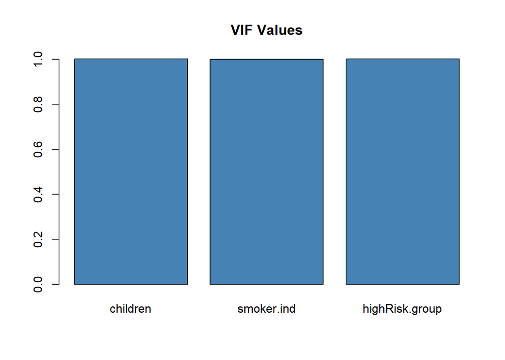

```r
#create horizontal bar chart to display each VIF value
barplot(vif(full.model), main = "VIF Values", horiz = FALSE, col = "steelblue")
```

## 4.2 Models Based on Box-Cox transformation

We first perform Box-Cox transformation and then choose appropriate transformations for both response and predictor variables to build candidate regression models.

## 4.3 Box-Cox Transformations

Since non-constant variance, we perform the Box-Cox procedure to search for a transformation of the response variable.

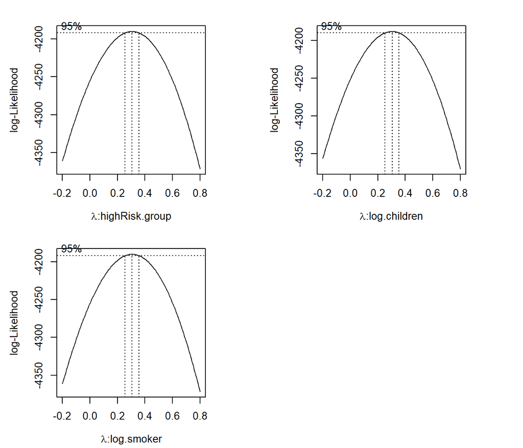

```r
par(pty = "s", mfrow = c(2, 2), oma=c(.1,.1,.1,.1), mar=c(4, 0, 2, 0))
##
boxcox(charges ~   children + smoker.ind +  highRisk.group,
       data = final.data, lambda = seq(-.2, .8, length = 10),
       xlab=expression(paste(lambda, ":highRisk.group")))
##
boxcox(charges ~   log(1+children) + smoker.ind +  highRisk.group,
       data = final.data, lambda = seq(-.2, .8, length = 10),
       xlab=expression(paste(lambda, ":log.children")))
##
boxcox(charges ~   children + log(1+smoker.ind) +  highRisk.group,
       data = final.data, lambda = seq(-.2, .8, length = 10),
       xlab=expression(paste(lambda, ":log.smoker")))
```

The above Box-cox transformation plots indicate the optimal $\lambda$. under different transformed predictor variables.

As a special power transformation, if $\lambda$=0, the transformation degenerates to log transformation.

## 4.4 Square-root Transformation

```r
sqrt.charges.log.children = lm((charges)^0.5 ~  log(1+children) + smoker.ind +  highRisk.group, data = final.data)
kable(summary(sqrt.charges.log.children)$coef, caption = "log-transformed model")
```

|  | Estimate | Std. Error | t value | Pr(>\|t\|) |
| --- | --- | --- | --- | --- |
| (Intercept) | 79.679510 | 1.279839 | 62.257435 | 0 |
| log(1 + children) | 9.472026 | 1.482694 | 6.388388 | 0 |
| smoker.ind | 89.589436 | 2.049306 | 43.716957 | 0 |
| highRisk.groupTRUE | 32.144720 | 4.205296 | 7.643867 | 0 |

Residual plots are given below.

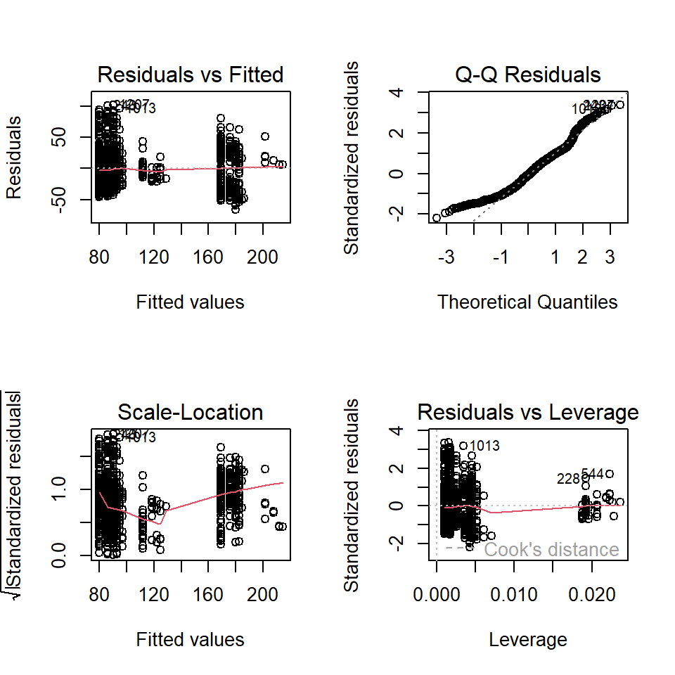

```r
par(mfrow = c(2,2))
plot(sqrt.charges.log.children)
```

There seems to be some improvement in the above residual diagnostic plots: the weak curve pattern has been lessened from the residual plot; yet the non-constant variance does not seem to be corrected. The violation of the normality assumption is also still an issue, but seems to be getting closer to normal.

## 4.5 Log-Transformation

```r
log.charges = lm(log(charges) ~  children + smoker.ind +  highRisk.group, data = final.data)
kable(summary(log.charges)$coef, caption = "log-transformed model")
```

log-transformed model

|  | Estimate | Std. Error | t value | Pr(>\|t\|) |
| --- | --- | --- | --- | --- |
| (Intercept) | 8.625668 | 0.0263023 | 327.943156 | 0 |
| children | 0.122707 | 0.0149442 | 8.211036 | 0 |
| smoker.ind | 1.519495 | 0.0446112 | 34.060856 | 0 |
| highRisk.groupTRUE | 0.680632 | 0.0915206 | 7.436927 | 0 |

Residual plots are given below.

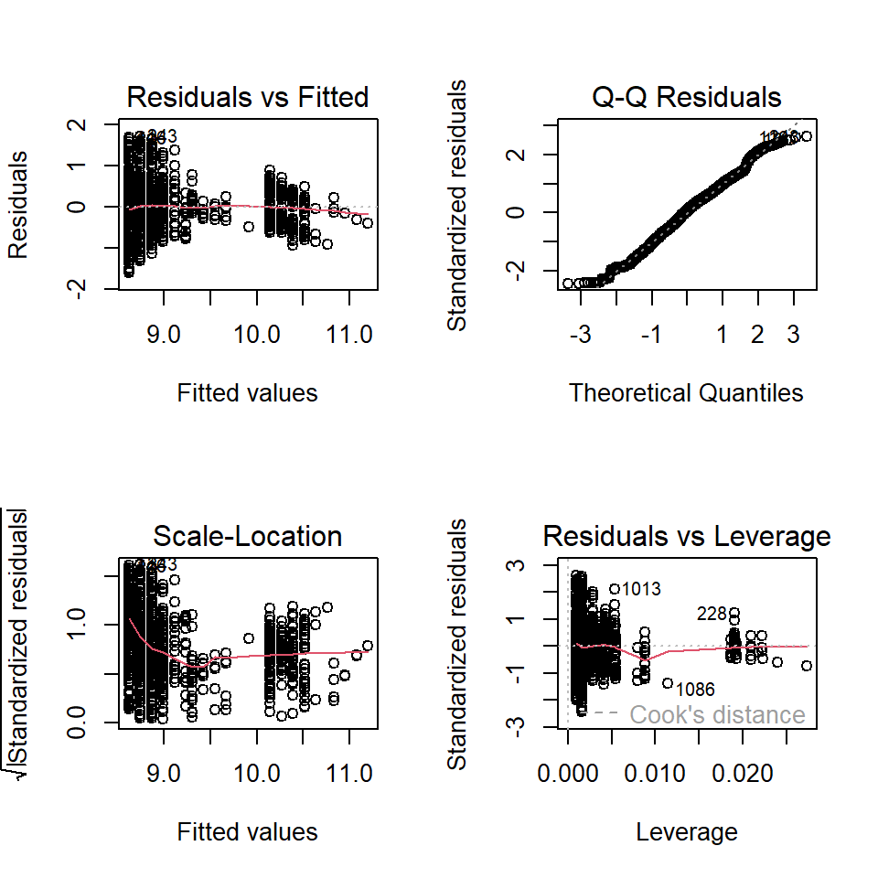

```r
par(mfrow = c(2,2))
plot(log.charges)
```

The above residual diagnostic plots are similar to that of the previous model. The Q-Q plots of all three models are similar to each other, this means that the assumption of normal residuals is not satisfied for all three models.

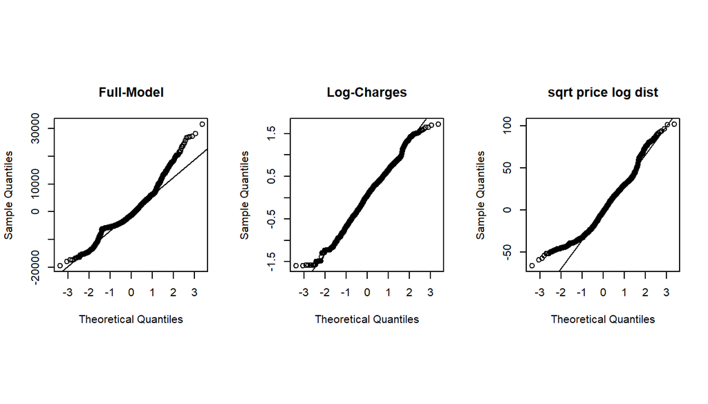

```r
#define plotting area
par(pty = "s", mfrow = c(1, 3))
#Q-Q plot for original model
qqnorm(full.model$residuals, main = "Full-Model")
qqline(full.model$residuals)
#Q-Q plot for Box-Cox transformed model
qqnorm(log.charges$residuals, main = "Log-Charges")
qqline(log.charges$residuals)
#display both Q-Q plots
qqnorm(sqrt.charges.log.children$residuals, main = "sqrt price log dist")
qqline(sqrt.charges.log.children$residuals)
```

## 4.6 Goodness-of-fit Measures

Next, we extract several other goodness-of-fit from each of the three candidate models and summarize them in the following table.

```r
select=function(m){ # m is an object: model
 e = m$resid                           # residuals
 n0 = length(e)                        # sample size
 SSE=(m$df)*(summary(m)$sigma)^2       # sum of squared error
 R.sq=summary(m)$r.squared             # Coefficient of determination: R square!
 R.adj=summary(m)$adj.r                # Adjusted R square
 MSE=(summary(m)$sigma)^2              # square error
 Cp=(SSE/MSE)-(n0-2*(n0-m$df))         # Mellow's p
 AIC=n0*log(SSE)-n0*log(n0)+2*(n0-m$df)          # Akaike information criterion
 SBC=n0*log(SSE)-n0*log(n0)+(log(n0))*(n0-m$df)  # Schwarz Bayesian Information criterion
 X=model.matrix(m)                     # design matrix of the model
 H=X%*%solve(t(X)%*%X)%*%t(X)          # hat matrix
 d=e/(1-diag(H))
 PRESS=t(d)%*%d   # predicted residual error sum of squares (PRESS)- a cross-validation measure
 tbl = as.data.frame(cbind(SSE=SSE, R.sq=R.sq, R.adj = R.adj, Cp = Cp, AIC = AIC, SBC = SBC, PRD = PRESS))
 names(tbl)=c("SSE", "R.sq", "R.adj", "Cp", "AIC", "SBC", "PRESS")
 tbl
 }
```

```r
output.sum = rbind(select(full.model), select(sqrt.charges.log.children), select(log.charges))
row.names(output.sum) = c("full.model", "sqrt.charges.log.children", "log.charges")
kable(output.sum, caption = "Goodness-of-fit Measures of Candidate Models")
```

Goodness-of-fit Measures of Candidate Models

|  | SSE | R.sq | R.adj | Cp | AIC | SBC | PRESS |
| --- | --- | --- | --- | --- | --- | --- | --- |
| full.model | 7.122027e+10 | 0.6367688 | 0.6359519 | 4 | 23811.170 | 23831.966 | 7.171906e+10 |
| sqrt.charges.log.children | 1.220043e+06 | 0.6001290 | 0.5992297 | 4 | 9127.093 | 9147.889 | 1.226152e+06 |
| log.charges | 5.782222e+02 | 0.4885134 | 0.4873631 | 4 | -1114.546 | -1093.750 | 5.804492e+02 |

## 4.7 Final Model

The inferential statistics of the final working model are summarized in the following table.

```r
kable(summary(full.model)$coef, caption = "Inferential Statistics of Final Model")
```

Inferential Statistics of Final Model

|  | Estimate | Std. Error | t value | Pr(>\|t\|) |
| --- | --- | --- | --- | --- |
| (Intercept) | 7417.0173 | 291.9098 | 25.408597 | 0.00e+00 |
| children | 659.0809 | 165.8539 | 3.973864 | 7.45e-05 |
| smoker.ind | 23667.5798 | 495.1060 | 47.803057 | 0.00e+00 |
| highRisk.groupTRUE | 7062.6952 | 1015.7184 | 6.953399 | 0.00e+00 |

Since the sample size (1338) is large, the argument for validating p-values is the Central Limit Theorem (CLT). all p-values are close to 0 meaning that all coefficients are significantly different from 0.

In this specific case study, there is no need to perform variable selection to determine the final model.

# 5 Summary of the model

We can explicitly write the final model in the following

$$full.model = 7417.0173 + 659.0809\times children + 23667.5798\times
smoker.ind + 7062.6952\times highRisk.groupTRUE$$
That is, as the number of children increases by one, the expected charges increase by 659.08 dollars, holding smoking status and risk group constant.

Similarly, being a smoker is associated with an increase of 23,667.58 dollars in charges compared to non-smokers. Being in the high-risk group is also positively associated with charges, with an expected increase of 7,062.70 dollars.

All predictors in this model are positively associated with charges.

# 6 Discussions

All candidate models have the same number of variables. We use commonly-used global goodness-of-fit measures as model selection criteria.

The violation of the normal assumption of the residuals remains uncorrected.